# Data 624 Homework 9 Chapter 8 Regression Trees and Rule-Based Models

Enid Roman

2024-11-12

### **8.1. Recreate the simulated data from Exercise 7.2:**

### **(a) Fit a random forest model to all of the predictors, then estimate the variable importance scores:**

|  | Overall |
| --- | --- |
| V1 | 8.6053659 |
| V2 | 6.8312592 |
| V3 | 0.7415349 |
| V4 | 7.8833841 |
| V5 | 2.2447503 |
| V6 | 0.1360542 |
| V7 | 0.0559509 |
| V8 | -0.0681958 |
| V9 | 0.0031962 |
| V10 | -0.0547059 |

### **Did the random forest model significantly use the uninformative predictors (V6 – V10)?**

To determine if the random forest model significantly used the uninformative predictors (V6–V10), we need to analyze the importance scores of these variables. Random forests assign an importance score to each feature, reflecting how much each variable contributes to improving the model’s predictive accuracy. Higher importance scores indicate more influential features, while lower scores show minimal or no contribution.

Given these observations, it appears that the random forest model did not rely significantly on V6–V10. Their minimal importance scores suggest they were either largely ignored in the decision splits or did not contribute positively to model accuracy, indicating they are uninformative in this setup.

In summary, based on the variable importance scores, the random forest model did not significantly use the uninformative predictors (V6–V10). This aligns with the expectation that these variables lack meaningful information for effective prediction in this context.

### **(b) Now add an additional predictor that is highly correlated with one of the informative predictors. For example:**

```
## [1] 0.9476651
```

### **Fit another random forest model to these data.**

|  | Overall |
| --- | --- |
| V1 | 5.2642601 |
| V2 | 6.0717543 |
| V3 | 0.5104075 |
| V4 | 6.8056776 |
| V5 | 2.1812743 |
| V6 | 0.2943445 |
| V7 | -0.0149050 |
| V8 | -0.0946168 |
| V9 | 0.0176924 |
| V10 | -0.0763153 |
| duplicate1 | 4.2867865 |

```
## [1] 0.9414424
```

|  | Overall |
| --- | --- |
| V1 | 4.2848843 |
| V2 | 6.4189248 |
| V3 | 0.3564442 |
| V4 | 6.7188576 |
| V5 | 1.8657590 |
| V6 | 0.2968678 |
| V7 | 0.0030368 |
| V8 | -0.0469257 |
| V9 | -0.0572195 |
| V10 | -0.0299011 |
| duplicate1 | 2.7121937 |
| duplicate2 | 3.2843725 |

### **(c) Use the cforest function in the party package to fit a random forest model using conditional inference trees. The party package function varimp can calculate predictor importance. The conditional argument of that function toggles between the traditional importance measure and the modified version described in Strobl et al. (2007). Do these importances show the same pattern as the traditional random forest model?**

Variable Importance (Unconditional)

| Variable | Importance |
| --- | --- |
| V1 | 3.3599062 |
| V2 | 5.2317332 |
| V3 | 0.0021304 |
| V4 | 6.9257293 |
| V5 | 1.4703217 |
| V6 | 0.0626435 |
| V7 | 0.0305772 |
| V8 | -0.0029718 |
| V9 | -0.0242242 |
| V10 | -0.0261708 |
| duplicate1 | 2.3413373 |
| duplicate2 | 3.8952317 |

Variable Importance (Conditional)

| Variable | Importance |
| --- | --- |
| V1 | 1.1701642 |
| V2 | 4.1737290 |
| V3 | -0.0019259 |
| V4 | 5.2999822 |
| V5 | 0.8793066 |
| V6 | 0.0455207 |
| V7 | -0.0079579 |
| V8 | 0.0075147 |
| V9 | 0.0019064 |
| V10 | -0.0101954 |
| duplicate1 | 0.6876771 |
| duplicate2 | 1.1431488 |

Both traditional random forest and cforest conditional importance measures assign high values to variables V1, V2, and V4, indicating these predictors are likely influential in both models.

Traditional importance for these variables is generally higher, suggesting some potential inflation in importance due to correlations or interactions, as cforest is designed to reduce this kind of bias.

In both methods, V6 to V10 exhibit near-zero or negative importance, reinforcing that these predictors are likely uninformative or redundant.

This low importance aligns well between both models, suggesting that the cforest model agrees with the traditional model in identifying these variables as less influential.

In both methods, V6 to V10 exhibit near-zero or negative importance, reinforcing that these predictors are likely uninformative or redundant.

This low importance aligns well between both models, suggesting that the cforest model agrees with the traditional model in identifying these variables as less influential.

The importance pattern between the cforest model and the traditional random forest is largely similar, with both identifying V1, V2, and V4 as important and V6 to V10 as uninformative. However, the conditional cforest model tends to reduce the inflated importance of highly correlated variables like the duplicates. This difference underscores cforest’s effectiveness in mitigating biases due to variable correlations, aligning with Strobl et al.’s findings (2007).

### **(d) Repeat this process with different tree models, such as boosted trees and Cubist. Does the same pattern occur?**

|  | var | rel.inf |
| --- | --- | --- |
| V4 | V4 | 26.8022751 |
| V2 | V2 | 20.7215937 |
| V1 | V1 | 14.8071934 |
| V5 | V5 | 11.0190400 |
| duplicate2 | duplicate2 | 8.2794921 |
| duplicate1 | duplicate1 | 7.5194197 |
| V3 | V3 | 7.2656566 |
| V7 | V7 | 1.1558453 |
| V6 | V6 | 1.0577820 |
| V8 | V8 | 0.5373390 |
| V9 | V9 | 0.4504699 |
| V10 | V10 | 0.3838930 |

The boosted tree model assigns high importance to V1, V2, and V4, consistent with the random forest models. V6 to V10 have low importance, indicating they are likely uninformative predictors.

|  | Overall |
| --- | --- |
| V1 | 72.0 |
| V2 | 54.5 |
| V4 | 49.0 |
| V3 | 42.0 |
| V5 | 40.0 |
| V6 | 11.0 |
| V7 | 0.0 |
| V8 | 0.0 |
| V9 | 0.0 |
| V10 | 0.0 |

To determine whether the variable importance patterns were consistent across different models (Random Forest models RF1, RF2, RF3, cforest with unconditional importance cfImp1, cforest with conditional importance cfImp2, Boosted Trees, and Cubist), we need to compare the importance scores of each predictor across all models.

V1 and V2 consistently have high importance scores across nearly all models. These variables are likely significant predictors, as they maintain high importance in both traditional and alternative tree-based methods.

V4 also appears with high importance in multiple models, though there may be slight variation in its rank relative to V1 and V2.

Variables V6 to V10 generally show low or even negative importance scores, indicating that these predictors are likely uninformative. Both the Random Forest and cforest models (conditional and unconditional) assign these variables low scores, aligning with the expectation that they contribute little to model performance.

Cubist and Boosted Trees models reinforce this pattern, with negligible importance for V6 to V10.

The duplicate variables (e.g., duplicate1 and duplicate2) display some importance in certain models, but their scores are generally lower than those of V1, V2, and V4. This suggests that while the duplicates provide some information, they do not add unique value beyond the original variables.

The conditional importance scores (cfImp2) tend to be more conservative than the unconditional scores (cfImp1). This is expected since conditional importance controls for correlations between predictors, often resulting in lower scores for variables that are redundant or collinear.

Conditional importance confirms the low utility of V6 to V10, further supporting the pattern observed in other models.

The general pattern of high importance for V1, V2, and V4, with low importance for V6 to V10, is consistent across models. This suggests robustness in identifying key predictors and uninformative variables, regardless of the model variation.

While there are slight differences in exact importance rankings, the top predictors remain largely the same, and the uninformative predictors are consistently minimized in importance.

In conclusion, the pattern of variable importance observed in the initial Random Forest model holds across boosted trees, cforest with conditional importance, and Cubist. This consistency indicates that V1, V2, and V4 are reliably important predictors, while V6 to V10 are largely uninformative across different modeling techniques.

### **8.2. Use a simulation to show tree bias with different granularities.**

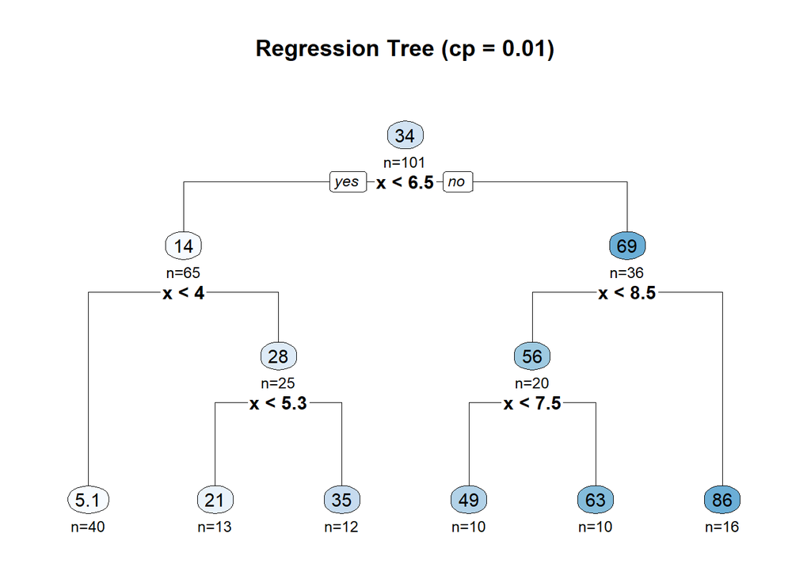

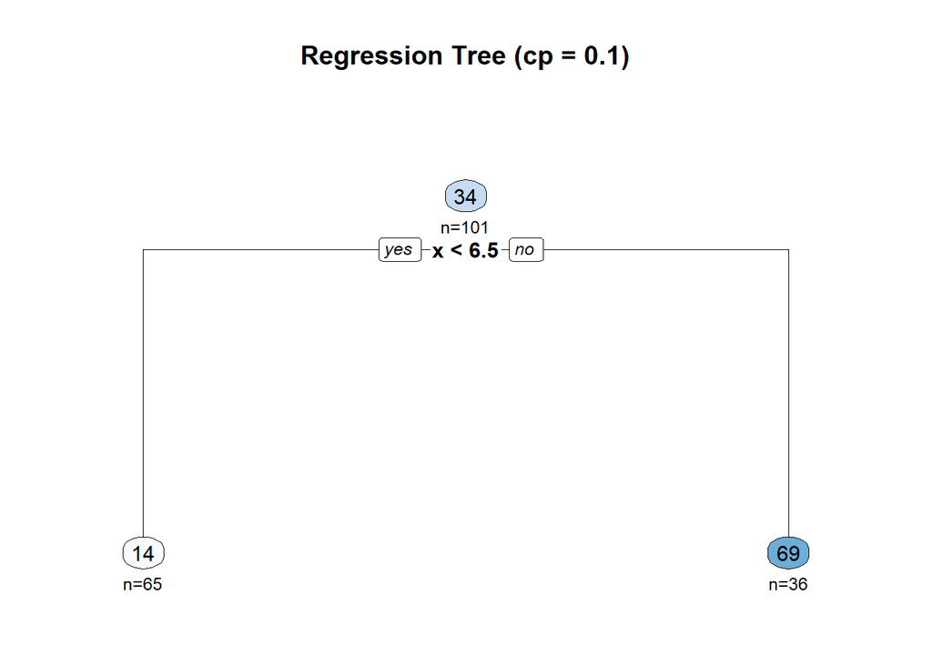

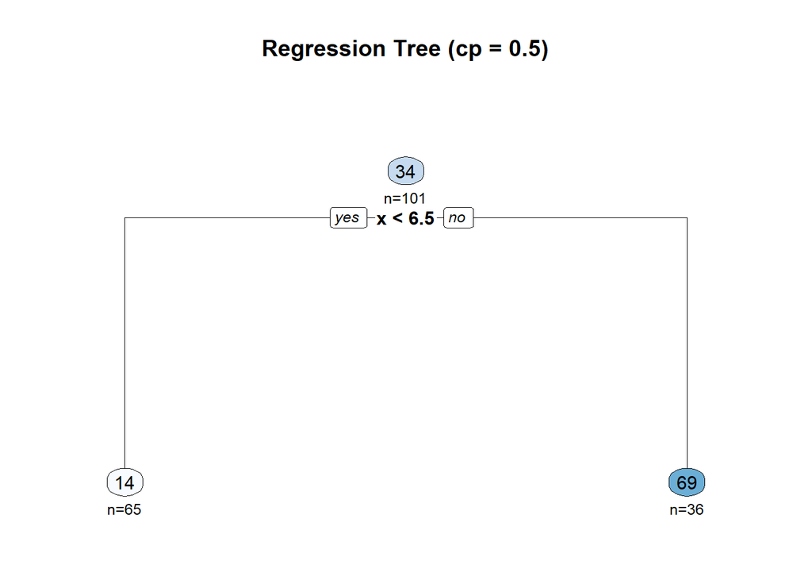

The regression trees with different complexities (cp = 0.01, cp = 0.1, cp = 0.5) demonstrate the impact of tree bias on model performance. As the complexity parameter (cp) increases, the tree becomes more pruned, leading to a simpler model with fewer splits.

In the first tree (cp = 0.01), the model is highly complex, capturing the quadratic relationship between x and y with multiple splits. This tree is likely overfitting the data, capturing noise rather than the underlying pattern.

The choice of complexity parameter (cp) influences the tree’s granularity, affecting the model’s ability to capture the underlying relationship in the data. By adjusting the cp value, we can control the trade-off between bias and variance, optimizing the model’s predictive performance.

In summary, the regression trees with different complexities illustrate the impact of tree bias on model interpretability and generalization. By tuning the complexity parameter, we can adjust the granularity of the tree to balance bias and variance, leading to more robust and accurate predictions.

### **8.3. In stochastic gradient boosting the bagging fraction and learning rate will govern the construction of the trees as they are guided by the gradient. Although the optimal values of these parameters should be obtained through the tuning process, it is helpful to understand how the magnitudes of these parameters affect magnitudes of variable importance. Figure 8.24 provides the variable importance plots for boosting using two extreme values for the bagging fraction (0.1 and 0.9) and the learning rate (0.1 and 0.9) for the solubility data. The left-hand plot has both parameters set to 0.1, and the right-hand plot has both set to 0.9:**

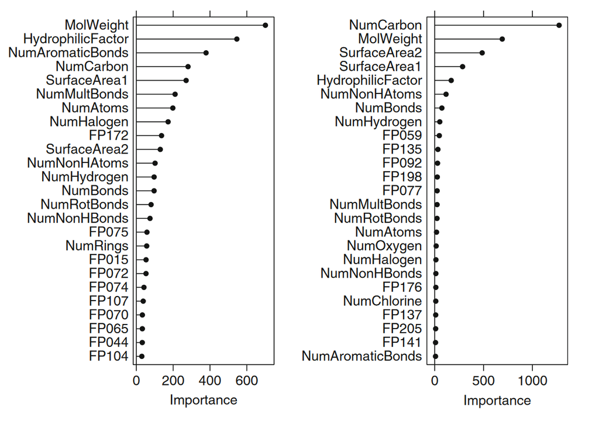

```r
# Load the necessary libraries
#library(magick)

knitr::include_graphics("C:/users/enidr/OneDrive/Documents/CUNY SPS DATA 624/Data 624 Week 12 HW 9/Screenshot 2024-11-12 004807.png")
```

### **(a) Why does the model on the right focus its importance on just the first few of predictors, whereas the model on the left spreads importance across more predictors?**

Here’s a detailed analysis of why the model on the right (with a high bagging fraction and learning rate of 0.9) focuses its importance on a few key predictors, while the model on the left (with a low bagging fraction and learning rate of 0.1) spreads importance across a broader set of predictors:

The learning rate controls how much each new tree contributes to the final model. A lower learning rate (as on the left) means that each tree has a smaller effect, allowing the model to gradually learn the relationships in the data. This slower learning process tends to engage a wider variety of predictors across the sequence of trees, as the model builds its understanding more evenly.

With a high learning rate (as on the right), each tree has a more significant impact on the model’s predictions. As a result, the model quickly converges on a few strong predictors that immediately improve predictive accuracy. This can lead to the concentration of importance on these primary predictors.

The bagging fraction (or subsample rate) controls the proportion of the training data used to build each tree. A low bagging fraction (left plot) introduces more randomness, causing the model to rely on a diverse set of predictors as each tree is fitted on a unique subset of data. This enhances the exploration of different predictors, leading to a more distributed importance profile.

A high bagging fraction (right plot) means that each tree uses a large portion of the data, allowing the model to focus on the most predictive features consistently across trees. Consequently, the model converges on a few dominant predictors, leading to a more concentrated importance on those variables.

When both the learning rate and bagging fraction are high (as in the right plot), the model learns quickly from a consistent subset of data, reinforcing the importance of the strongest predictors in each iteration. This rapid convergence prioritizes the few predictors that immediately improve model performance, leading to a skewed importance distribution.

In contrast, when both parameters are low (left plot), the model adopts a more conservative approach, exploring a broader range of predictors due to the randomness in sampling and the slower learning process. This results in a more spread-out variable importance, as more predictors are evaluated over time.

The model on the right emphasizes only a few predictors due to the high bagging fraction and learning rate, leading to a focus on the most predictive variables early in the boosting process. The model on the left, with lower values for both parameters, takes a more gradual and exploratory approach, assigning importance to a wider range of predictors across the boosting iterations. This highlights how tuning parameters in stochastic gradient boosting can impact the diversity and concentration of variable importance.

### **(b) Which model do you think would be more predictive of other samples?**

The model on the left, with a lower learning rate and bagging fraction, is likely to be more predictive of other samples for several reasons:

Lower learning rates and a lower bagging fraction introduce more randomness and slower learning, allowing the model to consider a broader range of features. This helps the model generalize better to unseen data, as it doesn’t become overly reliant on a few dominant predictors specific to the training data.

A model with high learning rates and high bagging fractions (right model) often risks overfitting to the specific patterns in the training set, especially if it quickly converges on a small set of strong predictors. This means it might perform well on the training data but less effectively on new samples that might have different feature distributions or noise.

The left model, with its spread-out importance, is more likely to capture a range of signals across various predictors, making it more robust to variations in other samples. This robustness can be especially valuable if future samples are expected to be somewhat different from the current training data.

While the model on the right may show higher accuracy on the current dataset, the model on the left is more likely to perform consistently across different samples, making it a more reliable choice for broader prediction tasks.

### **(c) How would increasing interaction depth affect the slope of predictor importance for either model in Fig. 8.24?**

Increasing the interaction depth (the maximum depth of each tree) in stochastic gradient boosting would likely cause the model to rely more heavily on higher-order interactions between predictors. This would impact the slope of predictor importance in both models shown in Fig. 8.24, but in slightly different ways depending on the other tuning parameters (bagging fraction and learning rate).

Here’s how increased interaction depth might affect each model:

Model on the Left (Low Learning Rate and Bagging Fraction):

With a low learning rate and low bagging fraction, increasing the interaction depth would allow the model to explore more complex relationships among the predictors, possibly spreading the importance even more across different predictors.

While it would still spread importance across many predictors, the increased interaction depth could accentuate the importance of some key predictors that are particularly relevant in multi-variable interactions. However, due to the low learning rate, this effect would be gradual, and the importance would likely remain more evenly distributed compared to the model on the right.

Model on the Right (High Learning Rate and Bagging Fraction):

With a high learning rate and high bagging fraction, increasing the interaction depth would likely amplify the focus on the top few predictors, resulting in an even steeper slope of importance. The model may quickly converge on strong predictor interactions that drive the response variable, further concentrating importance on a small subset of predictors.

A high interaction depth, combined with high learning rate and bagging fraction, can lead to overfitting, where the model heavily relies on complex interactions in the training data that may not generalize well to new samples. This would make the predictor importance even more skewed toward a few predictors, reflecting a narrow and potentially less generalizable focus.

Increased interaction depth would cause both models to place more emphasis on predictor interactions.

For the left model, this may lead to a modest increase in the importance of key predictors but would still maintain a broader distribution due to the lower learning rate.

For the right model, the increased interaction depth would likely sharpen the focus on a few top predictors, making the importance slope even steeper and potentially increasing the risk of overfitting.

The model on the right might become more predictive on training data with higher interaction depth but would likely be less generalizable to new data compared to the left model.

### **8.7. Refer to Exercises 6.3 and 7.5 which describe a chemical manufacturing process. Use the same data imputation, data splitting, and pre-processing steps as before and train several tree-based models:**

Data Imputation

```
## 'data.frame':    176 obs. of  58 variables:
##  $ Yield                 : num  38 42.4 42 41.4 42.5 ...
##  $ BiologicalMaterial01  : num  6.25 8.01 8.01 8.01 7.47 6.12 7.48 6.94 6.94 6.94 ...
##  $ BiologicalMaterial02  : num  49.6 61 61 61 63.3 ...
##  $ BiologicalMaterial03  : num  57 67.5 67.5 67.5 72.2 ...
##  $ BiologicalMaterial04  : num  12.7 14.6 14.6 14.6 14 ...
##  $ BiologicalMaterial05  : num  19.5 19.4 19.4 19.4 17.9 ...
##  $ BiologicalMaterial06  : num  43.7 53.1 53.1 53.1 54.7 ...
##  $ BiologicalMaterial07  : num  100 100 100 100 100 100 100 100 100 100 ...
##  $ BiologicalMaterial08  : num  16.7 19 19 19 18.2 ...
##  $ BiologicalMaterial09  : num  11.4 12.6 12.6 12.6 12.8 ...
##  $ BiologicalMaterial10  : num  3.46 3.46 3.46 3.46 3.05 3.78 3.04 3.85 3.85 3.85 ...
##  $ BiologicalMaterial11  : num  138 154 154 154 148 ...
##  $ BiologicalMaterial12  : num  18.8 21.1 21.1 21.1 21.1 ...
##  $ ManufacturingProcess01: num  NA 0 0 0 10.7 12 11.5 12 12 12 ...
```

[output cut: 44 more lines]

```
## [1] 106
```

```
## [1] 0
```

Split the data into training and test sets

```
## [1] 124  58
```

```
## [1] 52 58
```

Pre-process the data

```
## 'data.frame':    124 obs. of  58 variables:
##  $ Yield                 : num  -1.217 1.041 0.699 1.299 1.904 ...
##  $ BiologicalMaterial01  : num  -0.224 2.325 2.325 1.543 -0.412 ...
##  $ BiologicalMaterial02  : num  -1.567 1.281 1.281 1.872 0.629 ...
##  $ BiologicalMaterial03  : num  -2.6543 -0.0861 -0.0861 1.0795 -0.6164 ...
##  $ BiologicalMaterial04  : num  0.234 1.333 1.333 0.971 1.633 ...
##  $ BiologicalMaterial05  : num  0.496 0.413 0.413 -0.385 1.75 ...
##  $ BiologicalMaterial06  : num  -1.407 1.065 1.065 1.464 0.563 ...
##  $ BiologicalMaterial07  : num  -0.0898 -0.0898 -0.0898 -0.0898 -0.0898 ...
##  $ BiologicalMaterial08  : num  -1.24 2.36 2.36 1.12 1.24 ...
##  $ BiologicalMaterial09  : num  -3.308 -0.7 -0.7 -0.113 -1.687 ...
##  $ BiologicalMaterial10  : num  1.102 1.102 1.102 0.428 1.627 ...
##  $ BiologicalMaterial11  : num  -1.817 1.366 1.366 0.128 1 ...
##  $ BiologicalMaterial12  : num  -1.73 1.04 1.04 1.04 0.68 ...
##  $ ManufacturingProcess01: num  0.18 -6.353 -6.353 -0.327 0.405 ...
```

[output cut: 44 more lines]

```
## 'data.frame':    52 obs. of  58 variables:
##  $ Yield                 : num  1.271 1.652 1.618 0.402 -0.488 ...
##  $ BiologicalMaterial01  : num  2.325 1.558 0.775 2.094 1.601 ...
##  $ BiologicalMaterial02  : num  1.281 2.157 1.939 0.594 0.974 ...
##  $ BiologicalMaterial03  : num  -0.0861 1.1186 1.0331 -0.2156 -0.135 ...
##  $ BiologicalMaterial04  : num  1.333 0.856 1.938 1.754 1.949 ...
##  $ BiologicalMaterial05  : num  0.413 -0.495 0.446 1.239 1.756 ...
##  $ BiologicalMaterial06  : num  1.065 1.409 1.48 0.461 0.844 ...
##  $ BiologicalMaterial07  : num  -0.0898 -0.0898 -0.0898 -0.0898 -0.0898 ...
##  $ BiologicalMaterial08  : num  2.36 1.88 2.07 1.56 2.01 ...
##  $ BiologicalMaterial09  : num  -0.7 0.239 0.662 -0.348 0.31 ...
##  $ BiologicalMaterial10  : num  1.102 0.412 1.742 2.005 2.383 ...
##  $ BiologicalMaterial11  : num  1.3657 0.0257 1.474 1.1921 2.3237 ...
##  $ BiologicalMaterial12  : num  1.041 0.667 1.54 0.605 2.002 ...
##  $ ManufacturingProcess01: num  -6.353 0.124 0.405 -0.102 0.799 ...
```

[output cut: 44 more lines]

Train several tree-based models

Random Forest Variable Importance

|  | Overall |
| --- | --- |
| BiologicalMaterial01 | 1.0250689 |
| BiologicalMaterial02 | 1.4550055 |
| BiologicalMaterial03 | 5.9695779 |
| BiologicalMaterial04 | 2.4935383 |
| BiologicalMaterial05 | 0.7129550 |
| BiologicalMaterial06 | 3.7359421 |
| BiologicalMaterial07 | 0.0005086 |
| BiologicalMaterial08 | 1.4371030 |
| BiologicalMaterial09 | 1.3084073 |
| BiologicalMaterial10 | 0.6959830 |
| BiologicalMaterial11 | 2.9299639 |
| BiologicalMaterial12 | 6.1489521 |
| ManufacturingProcess01 | 0.9435431 |
| ManufacturingProcess02 | 0.6483790 |
| ManufacturingProcess03 | 0.3637617 |
| ManufacturingProcess04 | 0.5762328 |
| ManufacturingProcess05 | 1.1475834 |
| ManufacturingProcess06 | 2.6527207 |
| ManufacturingProcess07 | 0.0668778 |
| ManufacturingProcess08 | 0.1224550 |
| ManufacturingProcess09 | 3.4785271 |
| ManufacturingProcess10 | 0.9026901 |
| ManufacturingProcess11 | 2.0330432 |
| ManufacturingProcess12 | 0.4326927 |
| ManufacturingProcess13 | 2.8946511 |
| ManufacturingProcess14 | 1.1526189 |
| ManufacturingProcess15 | 1.5735640 |
| ManufacturingProcess16 | 0.8626007 |
| ManufacturingProcess17 | 5.8170626 |
| ManufacturingProcess18 | 1.4992938 |
| ManufacturingProcess19 | 1.4261193 |
| ManufacturingProcess20 | 1.4365852 |
| ManufacturingProcess21 | 1.6587681 |
| ManufacturingProcess22 | 0.6126686 |
| ManufacturingProcess23 | 0.8103363 |
| ManufacturingProcess24 | 1.1744794 |
| ManufacturingProcess25 | 1.0061482 |
| ManufacturingProcess26 | 0.7727862 |
| ManufacturingProcess27 | 0.8181480 |
| ManufacturingProcess28 | 3.9845243 |
| ManufacturingProcess29 | 1.0267283 |
| ManufacturingProcess30 | 1.2909734 |
| ManufacturingProcess31 | 6.6565852 |
| ManufacturingProcess32 | 33.0039965 |
| ManufacturingProcess33 | 0.7751148 |
| ManufacturingProcess34 | 0.3618439 |
| ManufacturingProcess35 | 0.6434773 |
| ManufacturingProcess36 | 1.6743117 |
| ManufacturingProcess37 | 1.0821300 |
| ManufacturingProcess38 | 0.1257839 |
| ManufacturingProcess39 | 1.3273693 |
| ManufacturingProcess40 | 0.0560122 |
| ManufacturingProcess41 | 0.3654626 |
| ManufacturingProcess42 | 0.6595481 |
| ManufacturingProcess43 | 0.3945774 |
| ManufacturingProcess44 | 0.2757154 |
| ManufacturingProcess45 | 0.3537814 |

Gradient Boosting Variable Importance

|  | Overall |
| --- | --- |
| BiologicalMaterial01 | 6.4341814 |
| BiologicalMaterial02 | 2.8127243 |
| BiologicalMaterial03 | 14.8459444 |
| BiologicalMaterial04 | 2.5890775 |
| BiologicalMaterial05 | 6.6833813 |
| BiologicalMaterial06 | 0.9957944 |
| BiologicalMaterial07 | 0.0000000 |
| BiologicalMaterial08 | 1.9293870 |
| BiologicalMaterial09 | 7.2278283 |
| BiologicalMaterial10 | 6.4850761 |
| BiologicalMaterial11 | 11.8184609 |
| BiologicalMaterial12 | 23.3544791 |
| ManufacturingProcess01 | 14.9190522 |
| ManufacturingProcess02 | 3.0785285 |
| ManufacturingProcess03 | 0.8368619 |
| ManufacturingProcess04 | 4.8241147 |
| ManufacturingProcess05 | 9.5715555 |
| ManufacturingProcess06 | 46.0552692 |
| ManufacturingProcess07 | 0.6198725 |
| ManufacturingProcess08 | 1.0742612 |
| ManufacturingProcess09 | 19.5011478 |
| ManufacturingProcess10 | 11.6925874 |
| ManufacturingProcess11 | 0.7219243 |
| ManufacturingProcess12 | 0.0000000 |
| ManufacturingProcess13 | 10.2311028 |
| ManufacturingProcess14 | 9.9916996 |
| ManufacturingProcess15 | 2.7262477 |
| ManufacturingProcess16 | 5.4975773 |
| ManufacturingProcess17 | 29.2255062 |
| ManufacturingProcess18 | 2.4795584 |
| ManufacturingProcess19 | 8.2243394 |
| ManufacturingProcess20 | 7.8010646 |
| ManufacturingProcess21 | 9.5239938 |
| ManufacturingProcess22 | 9.8349179 |
| ManufacturingProcess23 | 3.7286159 |
| ManufacturingProcess24 | 14.1616677 |
| ManufacturingProcess25 | 4.4557453 |
| ManufacturingProcess26 | 6.4343469 |
| ManufacturingProcess27 | 3.9392445 |
| ManufacturingProcess28 | 0.1363688 |
| ManufacturingProcess29 | 7.4740151 |
| ManufacturingProcess30 | 7.7532269 |
| ManufacturingProcess31 | 7.8154062 |
| ManufacturingProcess32 | 149.7787687 |
| ManufacturingProcess33 | 0.3485179 |
| ManufacturingProcess34 | 0.5070327 |
| ManufacturingProcess35 | 2.7553915 |
| ManufacturingProcess36 | 1.1289224 |
| ManufacturingProcess37 | 8.7236303 |
| ManufacturingProcess38 | 0.3696117 |
| ManufacturingProcess39 | 9.2049393 |
| ManufacturingProcess40 | 0.0000000 |
| ManufacturingProcess41 | 0.0000000 |
| ManufacturingProcess42 | 1.2032836 |
| ManufacturingProcess43 | 5.8319692 |
| ManufacturingProcess44 | 1.9204451 |
| ManufacturingProcess45 | 1.0357162 |

Cubist Variable Importance

|  | Overall |
| --- | --- |
| ManufacturingProcess17 | 42.5 |
| ManufacturingProcess39 | 21.0 |
| ManufacturingProcess32 | 47.5 |
| BiologicalMaterial12 | 22.0 |
| ManufacturingProcess31 | 4.0 |
| BiologicalMaterial05 | 2.5 |
| ManufacturingProcess06 | 14.0 |
| ManufacturingProcess22 | 1.0 |
| BiologicalMaterial04 | 3.0 |
| ManufacturingProcess29 | 14.5 |
| ManufacturingProcess25 | 14.5 |
| ManufacturingProcess09 | 12.5 |
| BiologicalMaterial03 | 11.0 |
| ManufacturingProcess13 | 10.5 |
| ManufacturingProcess33 | 10.5 |
| ManufacturingProcess11 | 10.0 |
| ManufacturingProcess26 | 8.0 |
| BiologicalMaterial08 | 8.0 |
| ManufacturingProcess24 | 8.0 |
| BiologicalMaterial09 | 7.5 |
| BiologicalMaterial02 | 7.0 |
| ManufacturingProcess27 | 7.0 |
| BiologicalMaterial06 | 5.0 |
| ManufacturingProcess18 | 4.0 |
| ManufacturingProcess16 | 3.5 |
| ManufacturingProcess15 | 3.5 |
| ManufacturingProcess20 | 3.5 |
| ManufacturingProcess04 | 3.0 |
| ManufacturingProcess03 | 2.5 |
| ManufacturingProcess23 | 2.5 |
| ManufacturingProcess05 | 2.0 |
| BiologicalMaterial10 | 2.0 |
| ManufacturingProcess12 | 2.0 |
| ManufacturingProcess19 | 2.0 |
| ManufacturingProcess21 | 2.0 |
| ManufacturingProcess01 | 1.5 |
| BiologicalMaterial11 | 1.5 |
| ManufacturingProcess43 | 1.0 |
| ManufacturingProcess02 | 1.0 |
| BiologicalMaterial01 | 0.0 |
| BiologicalMaterial07 | 0.0 |
| ManufacturingProcess07 | 0.0 |
| ManufacturingProcess08 | 0.0 |
| ManufacturingProcess10 | 0.0 |
| ManufacturingProcess14 | 0.0 |
| ManufacturingProcess28 | 0.0 |
| ManufacturingProcess30 | 0.0 |
| ManufacturingProcess34 | 0.0 |
| ManufacturingProcess35 | 0.0 |
| ManufacturingProcess36 | 0.0 |
| ManufacturingProcess37 | 0.0 |
| ManufacturingProcess38 | 0.0 |
| ManufacturingProcess40 | 0.0 |
| ManufacturingProcess41 | 0.0 |
| ManufacturingProcess42 | 0.0 |
| ManufacturingProcess44 | 0.0 |
| ManufacturingProcess45 | 0.0 |

Bagged Tree Variable Importance

|  | Overall |
| --- | --- |
| BiologicalMaterial01 | 0.1435384 |
| BiologicalMaterial02 | 0.1814203 |
| BiologicalMaterial03 | 0.5798112 |
| BiologicalMaterial04 | 0.2007435 |
| BiologicalMaterial05 | 0.2899065 |
| BiologicalMaterial06 | 0.2959157 |
| BiologicalMaterial07 | 0.0000000 |
| BiologicalMaterial08 | 0.2973043 |
| BiologicalMaterial09 | 0.3102775 |
| BiologicalMaterial10 | 0.1051152 |
| BiologicalMaterial11 | 0.5915191 |
| BiologicalMaterial12 | 0.8861626 |
| ManufacturingProcess01 | 0.2944574 |
| ManufacturingProcess02 | 0.1560424 |
| ManufacturingProcess03 | 0.0211690 |
| ManufacturingProcess04 | 0.1466957 |
| ManufacturingProcess05 | 0.1728725 |
| ManufacturingProcess06 | 0.5584584 |
| ManufacturingProcess07 | 0.0514549 |
| ManufacturingProcess08 | 0.0108126 |
| ManufacturingProcess09 | 0.6598441 |
| ManufacturingProcess10 | 0.2194264 |
| ManufacturingProcess11 | 0.5608103 |
| ManufacturingProcess12 | 0.0699787 |
| ManufacturingProcess13 | 0.5120909 |
| ManufacturingProcess14 | 0.3759635 |
| ManufacturingProcess15 | 0.4535918 |
| ManufacturingProcess16 | 0.2416880 |
| ManufacturingProcess17 | 1.0955617 |
| ManufacturingProcess18 | 0.2502621 |
| ManufacturingProcess19 | 0.3272336 |
| ManufacturingProcess20 | 0.2773384 |
| ManufacturingProcess21 | 0.3755464 |
| ManufacturingProcess22 | 0.0639143 |
| ManufacturingProcess23 | 0.1269655 |
| ManufacturingProcess24 | 0.2260277 |
| ManufacturingProcess25 | 0.2290149 |
| ManufacturingProcess26 | 0.1301623 |
| ManufacturingProcess27 | 0.2417423 |
| ManufacturingProcess28 | 0.4171542 |
| ManufacturingProcess29 | 0.1861834 |
| ManufacturingProcess30 | 0.3179287 |
| ManufacturingProcess31 | 0.7062981 |
| ManufacturingProcess32 | 0.7588114 |
| ManufacturingProcess33 | 0.0548682 |
| ManufacturingProcess34 | 0.0000000 |
| ManufacturingProcess35 | 0.1346992 |
| ManufacturingProcess36 | 0.0832284 |
| ManufacturingProcess37 | 0.1663320 |
| ManufacturingProcess38 | 0.0157006 |
| ManufacturingProcess39 | 0.1964913 |
| ManufacturingProcess40 | 0.0160962 |
| ManufacturingProcess41 | 0.0160962 |
| ManufacturingProcess42 | 0.1275682 |
| ManufacturingProcess43 | 0.1064286 |
| ManufacturingProcess44 | 0.0563482 |
| ManufacturingProcess45 | 0.1288447 |

### **(a) Which tree-based regression model gives the optimal resampling and test set performance?**

Performance Metrics for Tree-based Models

| Model | RMSE | Rsquared | MAE |
| --- | --- | --- | --- |
| Random Forest | 0.7014812 | 0.6604003 | 0.5401092 |
| Gradient Boosting | 0.6974752 | 0.6490253 | 0.5267574 |
| Cubist | 0.5656923 | 0.7543585 | 0.4446262 |
| Bagged Tree | 0.7269549 | 0.5957590 | 0.5366908 |

Based on the performance metrics provided, the Cubist model shows the best overall performance across the given metrics, indicating it likely gives the optimal resampling and test set performance among the listed tree-based regression models.

RMSE (Root Mean Squared Error): Lower RMSE values indicate better performance. The Cubist model has the lowest RMSE at 0.5657, indicating better prediction accuracy.

R² (R-squared): Higher R-squared values indicate better fit, with values closer to 1 being preferable. The Cubist model has the highest R-squared at 0.7544, indicating it explains the variance in the target variable better than the others.

MAE (Mean Absolute Error): Lower MAE values indicate better performance, reflecting smaller prediction errors. The Cubist model also has the lowest MAE at 0.4446, showing it has lower prediction errors on average.

### **(b) Which predictors are most important in the optimal tree-based regression model?**

|  | Overall |
| --- | --- |
| ManufacturingProcess32 | 100.00000 |
| ManufacturingProcess17 | 89.47368 |
| BiologicalMaterial12 | 46.31579 |
| ManufacturingProcess39 | 44.21053 |
| ManufacturingProcess29 | 30.52632 |
| ManufacturingProcess25 | 30.52632 |
| ManufacturingProcess06 | 29.47368 |
| ManufacturingProcess09 | 26.31579 |
| BiologicalMaterial03 | 23.15789 |
| ManufacturingProcess13 | 22.10526 |

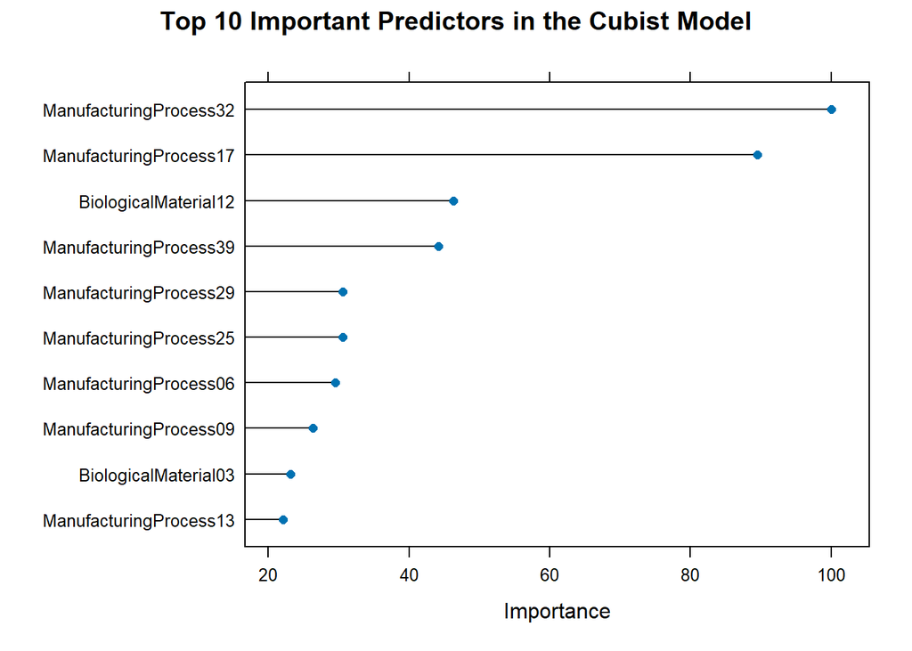

These predictors have been ranked based on their importance values, with ManufacturingProcess32 being the most influential predictor, followed by ManufacturingProcess17. The chart I created accurately reflects this ranking by displaying these predictors in descending order of importance.

### **Do either the biological or process variables dominate the list?**

Based on the top 10 important predictors you provided, it appears that the process variables dominate the list. Here’s a breakdown:

Process Variables:

ManufacturingProcess32 ManufacturingProcess17 ManufacturingProcess39 ManufacturingProcess29 ManufacturingProcess25 ManufacturingProcess06 ManufacturingProcess09 ManufacturingProcess13 There are 8 process-related variables in the top 10.

Biological Variables:

BiologicalMaterial12 BiologicalMaterial03

There are 2 biological variables in the top 10.

The process variables clearly dominate the list of top predictors, with 8 out of the top 10 most important predictors being related to manufacturing processes. This suggests that in this model, the manufacturing processes have a greater impact on the target variable than the biological materials.

### **How do the top 10 important predictors compare to the top 10 predictors from the optimal linear and nonlinear models?**

```
## ### Linear Regression Results ###
```

```
##      RMSE  Rsquared       MAE
## 0.8285972 0.5095169 0.6407973
```

```
## ### SVM Results ###
```

```
##      RMSE  Rsquared       MAE
## 0.7642341 0.5855119 0.5910040
```

```
## ### KNN Metrics Results ###
```

```
##      RMSE  Rsquared       MAE
## 0.8462222 0.4379732 0.7106254
```

```
## ### Neuro Network Metrics Results ###
```

```
##      RMSE  Rsquared       MAE
## 0.8993722 0.5441986 0.7042420
```

Linear Model Variable Importance

|  | Overall |
| --- | --- |
| BiologicalMaterial01 | 0.4144884 |
| BiologicalMaterial02 | 0.4183276 |
| BiologicalMaterial03 | 0.3296683 |
| BiologicalMaterial04 | 0.1004094 |
| BiologicalMaterial05 | 1.4830950 |
| BiologicalMaterial06 | 0.6722537 |
| BiologicalMaterial07 | 1.0122836 |
| BiologicalMaterial08 | 0.4479805 |
| BiologicalMaterial09 | 0.1656918 |
| BiologicalMaterial10 | 0.0016398 |
| BiologicalMaterial11 | 1.1880094 |
| BiologicalMaterial12 | 1.0740032 |
| ManufacturingProcess01 | 0.2780557 |
| ManufacturingProcess02 | 0.0016257 |
| ManufacturingProcess03 | 1.5058096 |
| ManufacturingProcess04 | 0.7357273 |
| ManufacturingProcess05 | 0.8834755 |
| ManufacturingProcess06 | 1.6381746 |
| ManufacturingProcess07 | 0.8857378 |
| ManufacturingProcess08 | 0.4512921 |
| ManufacturingProcess09 | 0.6382246 |
| ManufacturingProcess10 | 0.1007782 |
| ManufacturingProcess11 | 0.7667228 |
| ManufacturingProcess12 | 0.5933077 |
| ManufacturingProcess13 | 0.9720934 |
| ManufacturingProcess14 | 0.2959231 |
| ManufacturingProcess15 | 0.2557222 |
| ManufacturingProcess16 | 0.1957528 |
| ManufacturingProcess17 | 0.0743751 |
| ManufacturingProcess18 | 0.6963078 |
| ManufacturingProcess19 | 0.6411591 |
| ManufacturingProcess20 | 0.7223646 |
| ManufacturingProcess22 | 0.4755496 |
| ManufacturingProcess23 | 0.8996397 |
| ManufacturingProcess24 | 1.2013709 |
| ManufacturingProcess25 | 0.8672575 |
| ManufacturingProcess26 | 0.8041314 |
| ManufacturingProcess27 | 0.6766606 |
| ManufacturingProcess28 | 3.2011086 |
| ManufacturingProcess29 | 2.2099760 |
| ManufacturingProcess30 | 0.2744709 |
| ManufacturingProcess31 | 0.7048491 |
| ManufacturingProcess32 | 4.1098153 |
| ManufacturingProcess33 | 2.5217929 |
| ManufacturingProcess34 | 0.4899749 |
| ManufacturingProcess35 | 0.9323066 |
| ManufacturingProcess36 | 1.0568528 |
| ManufacturingProcess37 | 1.0046325 |
| ManufacturingProcess38 | 0.9991690 |
| ManufacturingProcess39 | 0.1916321 |
| ManufacturingProcess40 | 0.8355733 |
| ManufacturingProcess41 | 0.8810996 |
| ManufacturingProcess42 | 0.5277907 |
| ManufacturingProcess43 | 1.3659767 |
| ManufacturingProcess44 | 0.4718168 |
| ManufacturingProcess45 | 1.6214527 |

SVM Variable Importance

|  | Overall |
| --- | --- |
| BiologicalMaterial01 | 0.1076615 |
| BiologicalMaterial02 | 0.1807012 |
| BiologicalMaterial03 | 0.2631946 |
| BiologicalMaterial04 | 0.1413654 |
| BiologicalMaterial05 | 0.0367758 |
| BiologicalMaterial06 | 0.2909056 |
| BiologicalMaterial07 | 0.0100028 |
| BiologicalMaterial08 | 0.1473037 |
| BiologicalMaterial09 | 0.1555370 |
| BiologicalMaterial10 | 0.0724908 |
| BiologicalMaterial11 | 0.1629170 |
| BiologicalMaterial12 | 0.2412185 |
| ManufacturingProcess01 | 0.1578287 |
| ManufacturingProcess02 | 0.1331255 |
| ManufacturingProcess03 | 0.0129271 |
| ManufacturingProcess04 | 0.1098940 |
| ManufacturingProcess05 | 0.0161460 |
| ManufacturingProcess06 | 0.2402510 |
| ManufacturingProcess07 | 0.0007811 |
| ManufacturingProcess08 | 0.0000261 |
| ManufacturingProcess09 | 0.2587624 |
| ManufacturingProcess10 | 0.0708371 |
| ManufacturingProcess11 | 0.2043809 |
| ManufacturingProcess12 | 0.1571690 |
| ManufacturingProcess13 | 0.2747904 |
| ManufacturingProcess14 | 0.0641521 |
| ManufacturingProcess15 | 0.1395217 |
| ManufacturingProcess16 | 0.0643132 |
| ManufacturingProcess17 | 0.3063856 |
| ManufacturingProcess18 | 0.1083749 |
| ManufacturingProcess19 | 0.0718435 |
| ManufacturingProcess20 | 0.0401452 |
| ManufacturingProcess21 | 0.0590100 |
| ManufacturingProcess22 | 0.0028819 |
| ManufacturingProcess23 | 0.0132709 |
| ManufacturingProcess24 | 0.0670870 |
| ManufacturingProcess25 | 0.1663295 |
| ManufacturingProcess26 | 0.1076723 |
| ManufacturingProcess27 | 0.0729450 |
| ManufacturingProcess28 | 0.0776908 |
| ManufacturingProcess29 | 0.1889376 |
| ManufacturingProcess30 | 0.1247785 |
| ManufacturingProcess31 | 0.2174880 |
| ManufacturingProcess32 | 0.3734379 |
| ManufacturingProcess33 | 0.1850785 |
| ManufacturingProcess34 | 0.0183944 |
| ManufacturingProcess35 | 0.0719678 |
| ManufacturingProcess36 | 0.2131597 |
| ManufacturingProcess37 | 0.0537773 |
| ManufacturingProcess38 | 0.0032073 |
| ManufacturingProcess39 | 0.0018747 |
| ManufacturingProcess40 | 0.0008630 |
| ManufacturingProcess41 | 0.0003102 |
| ManufacturingProcess42 | 0.0001593 |
| ManufacturingProcess43 | 0.0288916 |
| ManufacturingProcess44 | 0.0056120 |
| ManufacturingProcess45 | 0.0016508 |

KNN Variable Importance

|  | Overall |
| --- | --- |
| BiologicalMaterial01 | 0.1076615 |
| BiologicalMaterial02 | 0.1807012 |
| BiologicalMaterial03 | 0.2631946 |
| BiologicalMaterial04 | 0.1413654 |
| BiologicalMaterial05 | 0.0367758 |
| BiologicalMaterial06 | 0.2909056 |
| BiologicalMaterial07 | 0.0100028 |
| BiologicalMaterial08 | 0.1473037 |
| BiologicalMaterial09 | 0.1555370 |
| BiologicalMaterial10 | 0.0724908 |
| BiologicalMaterial11 | 0.1629170 |
| BiologicalMaterial12 | 0.2412185 |
| ManufacturingProcess01 | 0.1578287 |
| ManufacturingProcess02 | 0.1331255 |
| ManufacturingProcess03 | 0.0129271 |
| ManufacturingProcess04 | 0.1098940 |
| ManufacturingProcess05 | 0.0161460 |
| ManufacturingProcess06 | 0.2402510 |
| ManufacturingProcess07 | 0.0007811 |
| ManufacturingProcess08 | 0.0000261 |
| ManufacturingProcess09 | 0.2587624 |
| ManufacturingProcess10 | 0.0708371 |
| ManufacturingProcess11 | 0.2043809 |
| ManufacturingProcess12 | 0.1571690 |
| ManufacturingProcess13 | 0.2747904 |
| ManufacturingProcess14 | 0.0641521 |
| ManufacturingProcess15 | 0.1395217 |
| ManufacturingProcess16 | 0.0643132 |
| ManufacturingProcess17 | 0.3063856 |
| ManufacturingProcess18 | 0.1083749 |
| ManufacturingProcess19 | 0.0718435 |
| ManufacturingProcess20 | 0.0401452 |
| ManufacturingProcess21 | 0.0590100 |
| ManufacturingProcess22 | 0.0028819 |
| ManufacturingProcess23 | 0.0132709 |
| ManufacturingProcess24 | 0.0670870 |
| ManufacturingProcess25 | 0.1663295 |
| ManufacturingProcess26 | 0.1076723 |
| ManufacturingProcess27 | 0.0729450 |
| ManufacturingProcess28 | 0.0776908 |
| ManufacturingProcess29 | 0.1889376 |
| ManufacturingProcess30 | 0.1247785 |
| ManufacturingProcess31 | 0.2174880 |
| ManufacturingProcess32 | 0.3734379 |
| ManufacturingProcess33 | 0.1850785 |
| ManufacturingProcess34 | 0.0183944 |
| ManufacturingProcess35 | 0.0719678 |
| ManufacturingProcess36 | 0.2131597 |
| ManufacturingProcess37 | 0.0537773 |
| ManufacturingProcess38 | 0.0032073 |
| ManufacturingProcess39 | 0.0018747 |
| ManufacturingProcess40 | 0.0008630 |
| ManufacturingProcess41 | 0.0003102 |
| ManufacturingProcess42 | 0.0001593 |
| ManufacturingProcess43 | 0.0288916 |
| ManufacturingProcess44 | 0.0056120 |
| ManufacturingProcess45 | 0.0016508 |

Neuro Network Variable Importance

|  | Overall |
| --- | --- |
| BiologicalMaterial01 | 0.7723617 |
| BiologicalMaterial02 | 0.2804983 |
| BiologicalMaterial03 | 0.7901909 |
| BiologicalMaterial04 | 1.7277147 |
| BiologicalMaterial05 | 3.2560049 |
| BiologicalMaterial06 | 0.3108047 |
| BiologicalMaterial07 | 0.2706206 |
| BiologicalMaterial08 | 1.0305662 |
| BiologicalMaterial09 | 1.4867648 |
| BiologicalMaterial10 | 2.1312740 |
| BiologicalMaterial11 | 1.9452196 |
| BiologicalMaterial12 | 1.1860290 |
| ManufacturingProcess01 | 1.8214109 |
| ManufacturingProcess02 | 0.8447873 |
| ManufacturingProcess03 | 2.3812633 |
| ManufacturingProcess04 | 3.1753533 |
| ManufacturingProcess05 | 2.1955969 |
| ManufacturingProcess06 | 2.8088904 |
| ManufacturingProcess07 | 1.3537290 |
| ManufacturingProcess08 | 1.0890765 |
| ManufacturingProcess09 | 3.2152691 |
| ManufacturingProcess10 | 1.6766743 |
| ManufacturingProcess11 | 1.5229254 |
| ManufacturingProcess12 | 2.3792366 |
| ManufacturingProcess13 | 3.3285803 |
| ManufacturingProcess14 | 1.0474859 |
| ManufacturingProcess15 | 0.9919241 |
| ManufacturingProcess16 | 0.6012087 |
| ManufacturingProcess17 | 2.4083483 |
| ManufacturingProcess18 | 0.7388137 |
| ManufacturingProcess19 | 2.6871357 |
| ManufacturingProcess20 | 0.7940063 |
| ManufacturingProcess21 | 0.8359628 |
| ManufacturingProcess22 | 1.7166856 |
| ManufacturingProcess23 | 1.9142858 |
| ManufacturingProcess24 | 3.7776712 |
| ManufacturingProcess25 | 0.1586315 |
| ManufacturingProcess26 | 0.4912437 |
| ManufacturingProcess27 | 0.3799888 |
| ManufacturingProcess28 | 3.3811218 |
| ManufacturingProcess29 | 2.5123412 |
| ManufacturingProcess30 | 0.6572429 |
| ManufacturingProcess31 | 1.0279280 |
| ManufacturingProcess32 | 9.4391202 |
| ManufacturingProcess33 | 1.7215565 |
| ManufacturingProcess34 | 1.0269644 |
| ManufacturingProcess35 | 0.6682380 |
| ManufacturingProcess36 | 2.3534155 |
| ManufacturingProcess37 | 3.4206330 |
| ManufacturingProcess38 | 0.8200280 |
| ManufacturingProcess39 | 3.8372936 |
| ManufacturingProcess40 | 1.0862780 |
| ManufacturingProcess41 | 1.2860056 |
| ManufacturingProcess42 | 0.6907966 |
| ManufacturingProcess43 | 1.2595291 |
| ManufacturingProcess44 | 1.8477924 |
| ManufacturingProcess45 | 1.4394803 |

|  | Overall |
| --- | --- |
| ManufacturingProcess32 | 100.00000 |
| ManufacturingProcess28 | 77.88060 |
| ManufacturingProcess33 | 61.34496 |
| ManufacturingProcess29 | 53.75483 |
| ManufacturingProcess06 | 39.83626 |
| ManufacturingProcess45 | 39.42922 |
| ManufacturingProcess03 | 36.61428 |
| BiologicalMaterial05 | 36.06137 |
| ManufacturingProcess43 | 33.21052 |
| ManufacturingProcess24 | 29.20374 |

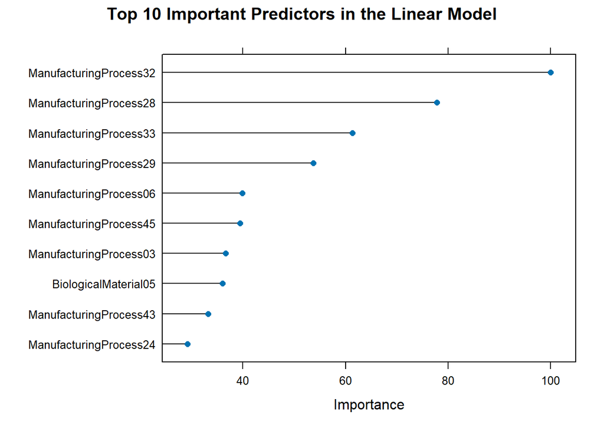

|  | Overall |
| --- | --- |
| ManufacturingProcess32 | 100.00000 |
| ManufacturingProcess17 | 82.04335 |
| BiologicalMaterial06 | 77.89778 |
| ManufacturingProcess13 | 73.58212 |
| BiologicalMaterial03 | 70.47676 |
| ManufacturingProcess09 | 69.28981 |
| BiologicalMaterial12 | 64.59155 |
| ManufacturingProcess06 | 64.33243 |
| ManufacturingProcess31 | 58.23648 |
| ManufacturingProcess36 | 57.07735 |

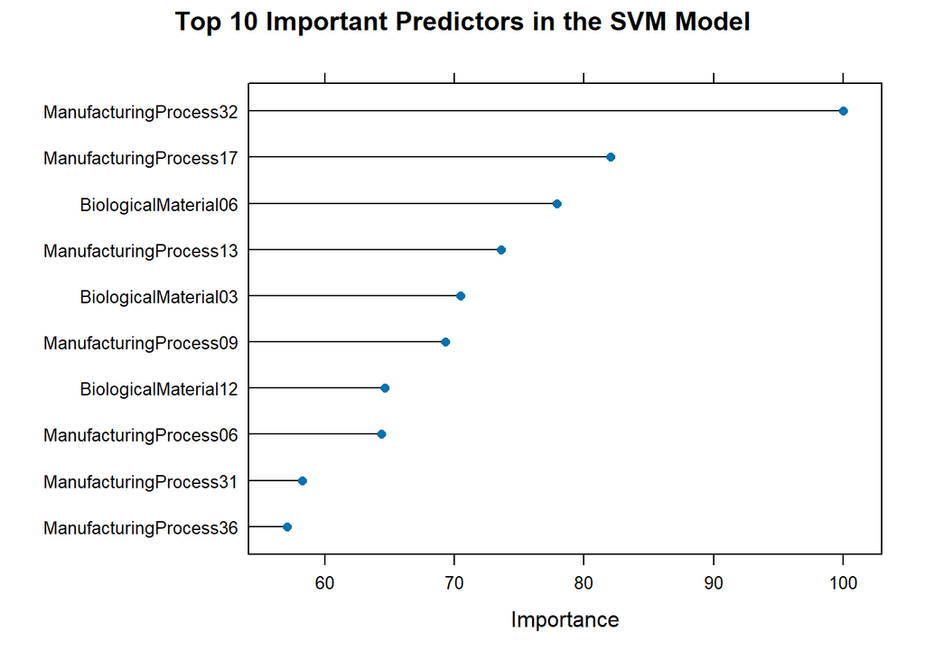

|  | Overall |
| --- | --- |
| ManufacturingProcess32 | 100.00000 |
| ManufacturingProcess17 | 82.04335 |
| BiologicalMaterial06 | 77.89778 |
| ManufacturingProcess13 | 73.58212 |
| BiologicalMaterial03 | 70.47676 |
| ManufacturingProcess09 | 69.28981 |
| BiologicalMaterial12 | 64.59155 |
| ManufacturingProcess06 | 64.33243 |
| ManufacturingProcess31 | 58.23648 |
| ManufacturingProcess36 | 57.07735 |

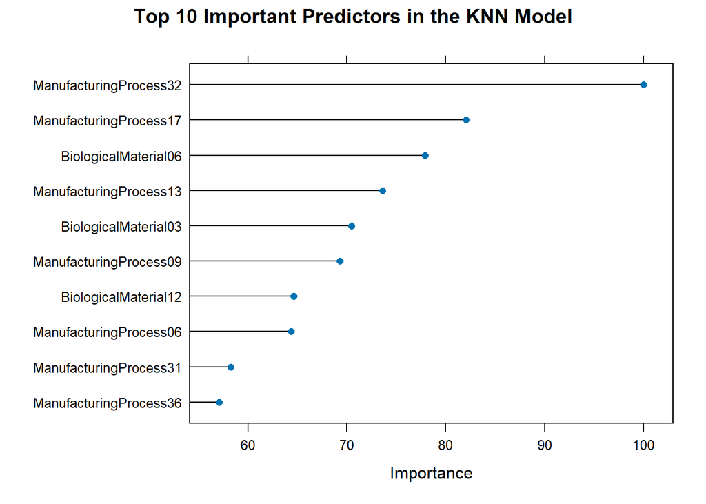

|  | Overall |
| --- | --- |
| ManufacturingProcess32 | 100.00000 |
| ManufacturingProcess39 | 39.63867 |
| ManufacturingProcess24 | 38.99622 |
| ManufacturingProcess37 | 35.14903 |
| ManufacturingProcess28 | 34.72328 |
| ManufacturingProcess13 | 34.15713 |
| BiologicalMaterial05 | 33.37511 |
| ManufacturingProcess09 | 32.93617 |
| ManufacturingProcess04 | 32.50607 |
| ManufacturingProcess06 | 28.55732 |

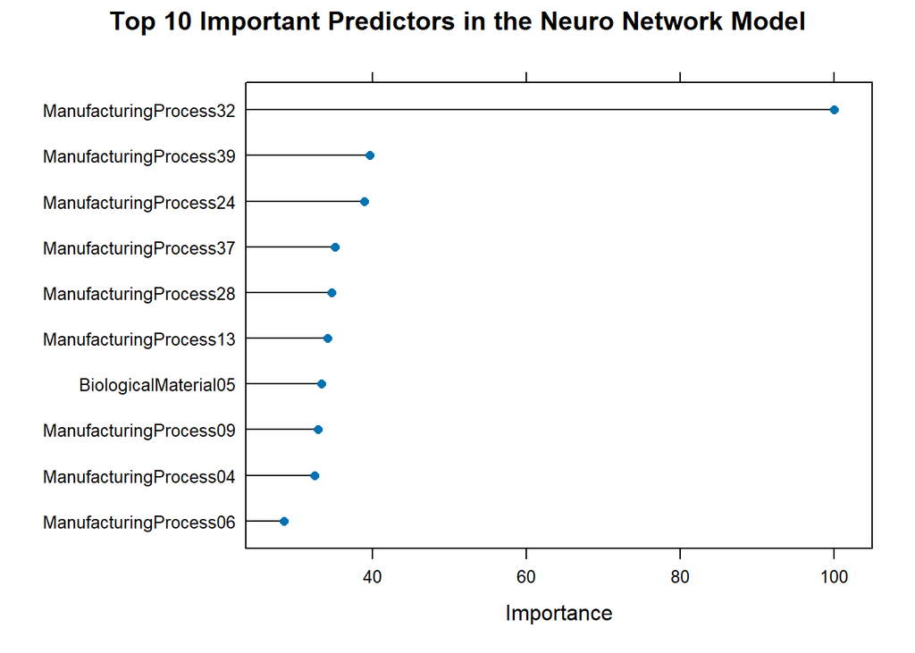

To compare the top 10 important predictors across the optimal Cubist, Linear, SVM, KNN, and Neural Network models, we can focus on identifying patterns and any overlapping predictors. Here are the key observations:

Comparison and Analysis of Top 10 Important Predictors:

Common Predictors Across Models:

ManufacturingProcess32 appears as the top predictor in almost all models (Cubist, Linear, SVM, KNN, and Neural Network), indicating it has strong predictive power across both linear and nonlinear models.

ManufacturingProcess06 is also a common predictor across all models, indicating its consistent importance.

ManufacturingProcess09 and ManufacturingProcess13 appear frequently, showing up in most models.

Biological Variables Across Models:

In the Cubist model, BiologicalMaterial12 and BiologicalMaterial03 are important.

In the SVM and KNN models, BiologicalMaterial06 and BiologicalMaterial03 are among the top predictors.

The Neural Network model includes BiologicalMaterial05 in its top predictors.

Linear Model has BiologicalMaterial05 in its top 10 as well.

This suggests that while biological variables are important, the specific biological predictor differs slightly depending on the model.

Process Variables Dominance:

Across all models, process-related variables dominate the list of top predictors, indicating that manufacturing processes are generally more influential in predicting the target variable.

Models like the Linear Model and Neural Network tend to favor more unique process-related variables such as ManufacturingProcess28, ManufacturingProcess33, ManufacturingProcess24, and ManufacturingProcess45.

Insights and Interpretation of Variable Importance:

Consistency Across Models:

Some predictors, like ManufacturingProcess32 and ManufacturingProcess06, are consistently important across all models. This consistency suggests these predictors have a strong and likely linear relationship with the target variable, making them valuable regardless of model complexity.

Variability with Model Type:

The Cubist and SVM models tend to include a mix of both manufacturing process variables and biological material variables, indicating that these models might capture more nuanced interactions between biological and process-related factors.

The Neural Network model, known for capturing complex patterns, still ranks process-related variables highly, but includes some biological materials that may interact nonlinearly with the process variables.

Model-Specific Important Variables:

Certain variables are more model-specific, such as ManufacturingProcess45 in the Linear model or ManufacturingProcess04 in the Neural Network model. These variables might have non-linear or interaction effects that are better captured by specific model structures.

ManufacturingProcess32 and ManufacturingProcess06 emerge as the most critical predictors across different model types, indicating their fundamental importance to the target variable. Process variables generally dominate the top predictor list, but the inclusion of biological variables varies by model, with some models (e.g., SVM and KNN) including multiple biological materials. This analysis suggests that while process variables are consistently impactful, certain biological factors play a secondary role, especially in nonlinear models like SVM and KNN.

### **(c) Plot the optimal single tree with the distribution of yield in the terminal nodes.**

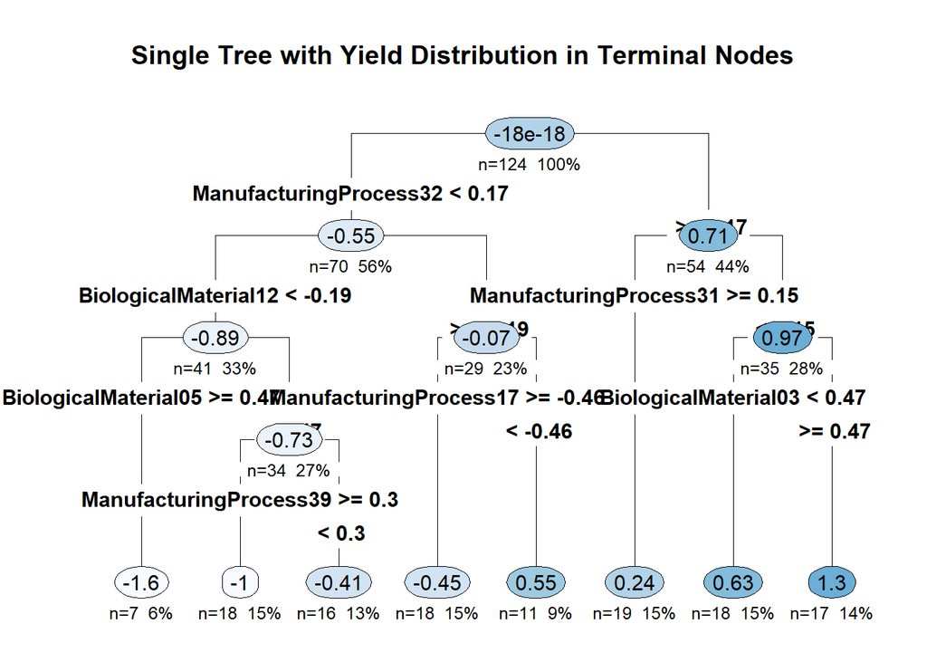

### **Does this view of the data provide additional knowledge about the biological or process predictors and their relationship with yield?**

Yes, this decision tree provides additional insights into the relationship between the biological and process predictors with yield. Here’s a breakdown of the knowledge we can gain from this tree visualization:

Hierarchical Structure and Importance

ManufacturingProcess32 is the root node, which implies it is the most critical variable in determining yield. The first split based on ManufacturingProcess32 indicates that variations in this predictor have a substantial impact on yield, setting the primary direction for the rest of the splits.

The next most important predictors are BiologicalMaterial12 and ManufacturingProcess31, as they are immediately involved in the subsequent splits. This hierarchical ordering implies that ManufacturingProcess32, ManufacturingProcess31, and BiologicalMaterial12 are likely the most influential in determining yield outcomes.

Relationship Patterns in Predictors For nodes where ManufacturingProcess32 is below 0.17, the model further segments based on BiologicalMaterial12. This suggests that BiologicalMaterial12 plays a significant role in explaining yield variability when ManufacturingProcess32 is low.

For nodes where ManufacturingProcess32 is above 0.17, ManufacturingProcess31 and BiologicalMaterial03 play a crucial role, with specific thresholds of 0.15 and 0.47, respectively. This indicates that BiologicalMaterial03 becomes more important in determining yield under certain conditions of ManufacturingProcess31.

Interaction Effects

A similar interaction is seen with ManufacturingProcess31 and BiologicalMaterial03 on the right side of the tree, where the yield outcomes vary based on both the values of ManufacturingProcess31 and BiologicalMaterial03.

Yield Predictions at Terminal Nodes

Each terminal node represents a different yield outcome, with values that range from negative (e.g., -1.6) to positive (e.g., 1.3).

Threshold Effects

Interpretation of Biological vs. Process Variables

Process Variables: ManufacturingProcess32 and ManufacturingProcess31 have the largest impact, suggesting that optimizing these process parameters could lead to better yield.

Biological Variables: Although BiologicalMaterial12 and BiologicalMaterial03 are less dominant than the main process variables, they still play a significant role, especially under specific conditions of the process variables. This indicates that the biological variables act as secondary factors, influencing yield in the presence of certain process conditions.

This decision tree offers a more nuanced understanding of how both biological and process variables interact to influence yield. The hierarchical splits and interactions reveal that:

Process variables like ManufacturingProcess32 and ManufacturingProcess31 are primary drivers. Biological variables have an additive effect, refining the yield prediction under certain process conditions.

Thresholds identified in this tree provide actionable points that could be used for process optimization, helping to achieve a higher yield by controlling specific variables.

This visualization is valuable for understanding not just the importance of each variable but also how combinations of biological and process factors jointly impact yield outcomes.